# Centrality measures as a proxy for causal influence?

13th December, 2018

## Context

- **Theory:**
  1. Like Phlogiston, fairies and witches, latent variables need to be abandoned
  2. Psychological disorders are a 'network' of causally interacting symptoms (Borsboom, 2017)
- **Practice:**
  1. Estimate *statistical models* such as the Gaussian graphical model on cross-sectional data
  2. Visualize the network
  3. Compute so-called *centrality* measures for each node
  4. Interpret high scoring nodes as *important*, suggest them as intervention targets

## Context

- **Examples:**
  - Stochl et al. (2018) studied well-being and find that 3 items are consistently the most central items
  - McNally et al. (2015) studied earthquake victims suffering PTSD (use the word *causal* 59 times)

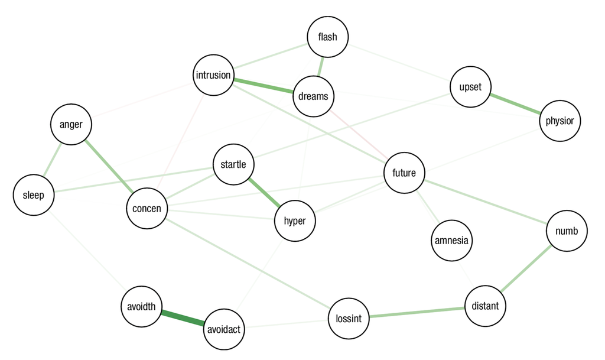

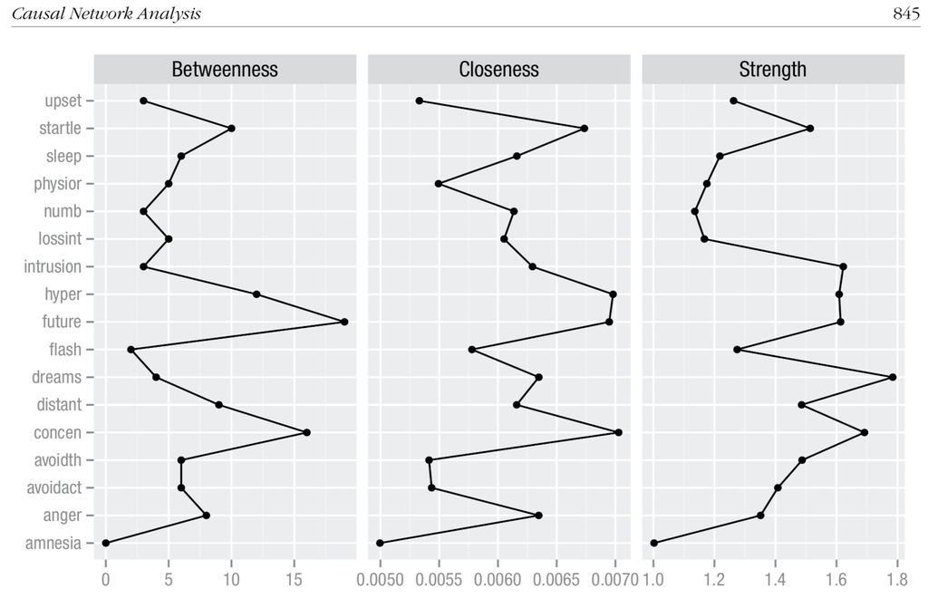

## Causality

- Intervention is a causal notion!
- The dominant causal inference framework is based on DAGs

[figure not shown]

- Textbook example:
  - Strong correlation between number of storks (\(X\)) and number of human babies delivered (\(Y\); Matthews, 2000)
  - If we condition on economic development (\(Z\)), then \(X\) and \(Y\) are independent

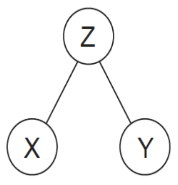

## Causality

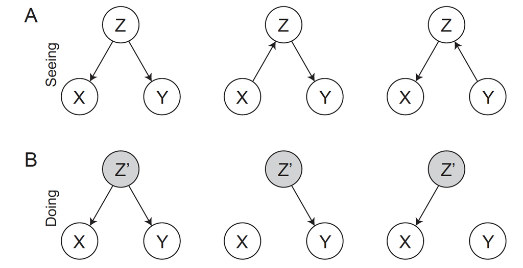

## Toy examples

- Three ways in which information gets lost when moving from DAGs to MRFs
  1. Loss of directionality
  2. Conditioning on *colliders* introduces new undirected edges
  3. Multiple *Markov equivalent* DAGs can map to the same MRFs

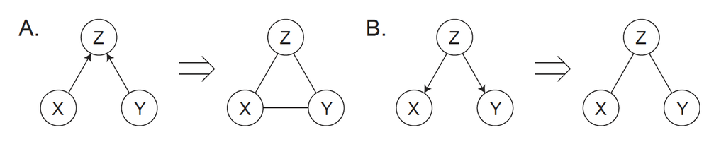

## Scale it up!

1. Simulate data from a DAG
2. Estimate MRF
3. Compare true causal influence of nodes to their estimated centrality scores
4. Observe how it changes as a function of network structure, network density, and number of nodes

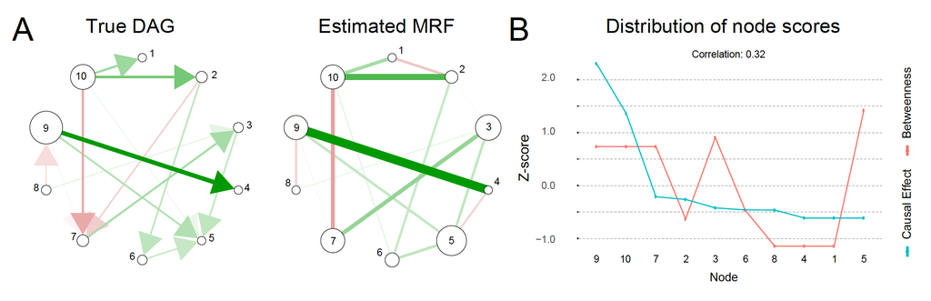

## Shiny App

- [Shiny App](https://fdabl.shinyapps.io/causality-centrality-app/)

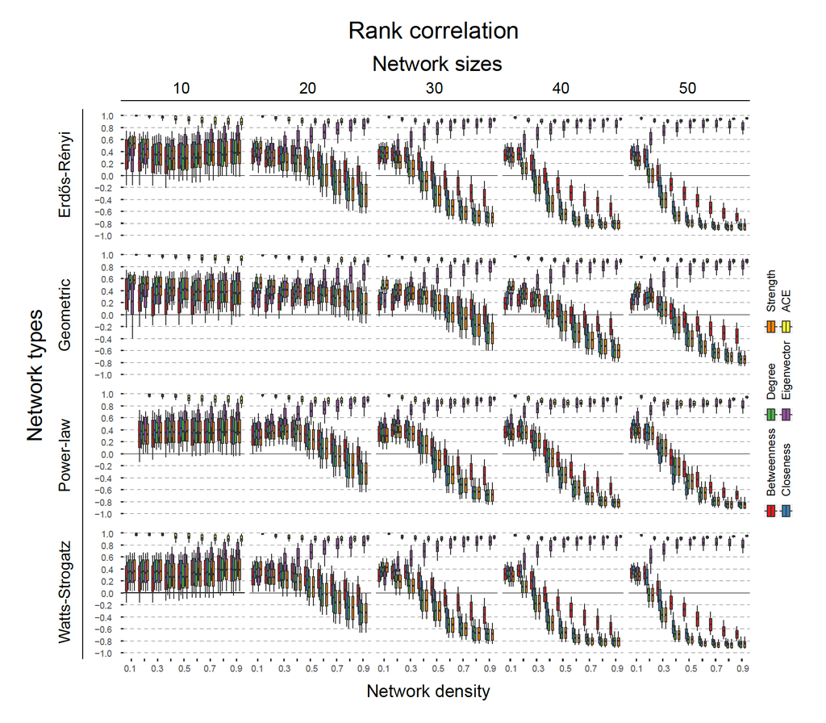

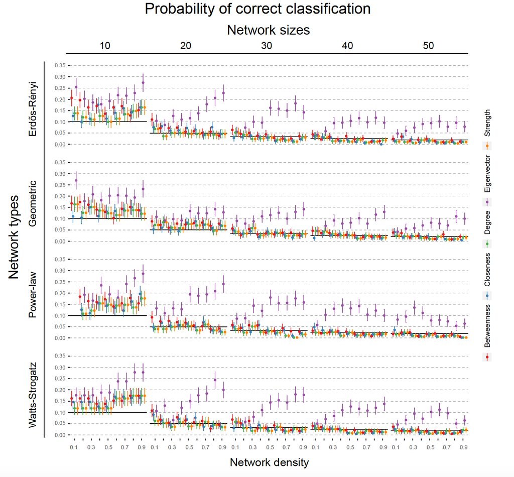

## Discussion

- All centrality measures except *eigenvector centrality* show a similar trend
  - Correlation decreases with network density and graph size
  - This is because distribution over centrality scores & causal influence differ in skew
- Why do they differ in skew?
  - DAGs are a hierarchical ordered system of (linear) equations
  - Thus, nodes higher up the hierarchy have more pronounced causal influence
  - In contrast, MRFs drop directionality, thus obscuring this hierarchy
  - Moreover, MRFs 'marry parents' which bumps up the score of leaf nodes
  - This effect is stronger with increased network density, creating strong right-skew
- Eigenvector centrality takes into account the importance of its neighbours
  - This propagates 'back', such that right-skew cannot occur
  - Therefore, the correlation is strong even with high network density

## Conclusion

- We have illustrated the (not so?) obvious
  1. Centrality measures do not straightforwardly map to causal influence
  2. (Single-symptom) interventions based on centrality measures may thus be misguided
- What does centrality mean in psychological networks, anyway (see also Bringmann et al., 2018)?
- I think of them as *Cargo cult measures* (see Feynman, 1974)

## Limitations

- **Our conclusions are *conditional* on the assumptions that causal DAGs are a good idea!**
- First, interpreting DAGs causally requires two important assumptions
  1. **The causal Markov condition** (see Cartwright, 1999; Dawid, 2010a,b)
  2. **Faithfulness** (see Ramsey, 2010)
- Second, DAGs may be inherently limited (e.g., they disallow cycles)
- Denny already argued in 2010 that DAGs are the wrong formalism for psychological phenomena
- Natural extension: take a dynamical model as ground truth instead of DAGs
- Check whether centrality measures recover meaningful patterns
- In that sense, the paper Max Hinne and I wrote is a kind of *Wittgenstein's ladder*
- Still, it seems we are trapped between a rock and a hard place!

## Limitations

[figure not shown]

## Ways forward

- Work out a different formalism that improves on DAGs and MRFs (e.g., Lauritzen & Richardson, 2002)
  - But that would still be cross-sectional
- Bite the Pearlian bullet (in a good sense)
  - Try to combine experimental with observational data (Barenboim & Pearl, 2016)
  - Use quasi-experimental techniques to establish causality (Marinescu et al., 2018)
- Use intensive time-series data
  - Continuous time modeling (Ryan et al., 2018)
- Develope *theoretical models* that explain empirical findings and predict new ones
  - Mutualism in intelligence research (van der Maas et al., 2006)
  - Panic disorder in clinical psychology (Robinaugh et al., still in progress)
  - Attitudes in social psychology (Dalege, et al. 2016)

## Thanks!

- Preprint available at https://psyarxiv.com/nue4z/
- Other stuff on Twitter @fdabl